# AccSamplingDesign: Acceptance Sampling Plan Design - R Package

Ha Truong

2025-03-11

# 1. Introduction

The AccSamplingDesign package provides tools for designing acceptance sampling plans for both attribute and variable data. Key features include:

- **Attribute sampling plans** (pass/fail inspection based on nonconforming proportion)
- **Variable sampling plans** for normal and beta distributions, focusing on the proportion of nonconforming units
- **Measurement error adjustments** to account for variability in the data
- **OC curve visualization** to evaluate sampling plan performance
- **Risk-based optimization** to minimize producer’s and consumer’s risks while meeting specified quality levels of Producer’s Risk Quality (PRQ) and Consumer’s Risk Quality (CRQ)

# 2. Installation

```r
# Install from GitHub
devtools::install_github("vietha/AccSamplingDesign")

# Load package
library(AccSamplingDesign)
```

# 3. Attribute Sampling Plans

## 3.1 Create Attribute Plan

```r
plan_attr <- optAttrPlan(
  PRQ = 0.01,  # Acceptable Quality Level (1% defects)
  CRQ = 0.05,  # Rejectable Quality Level (5% defects)
  alpha = 0.05, # Producer's risk
  beta = 0.10   # Consumer's risk
)
```

## 3.2 Plan Summary

```r
summary(plan_attr)
```

```
#> Attribute Acceptance Sampling Plan
#> ----------------------------------
#> Sample Size (n): 132
#> Acceptance Number (c): 3
#> Producer's Risk (alpha = 0.04425251 ) at PRQ = 0.01
#> Consumer's Risk (beta = 0.0992283 ) at CRQ = 0.05
```

## 3.3 Acceptance Probability

```r
# Probability of accepting 3% defective lots
accProb(plan_attr, 0.03)
```

```
#> [1] 0.4384354
```

## 3.4 OC Curve

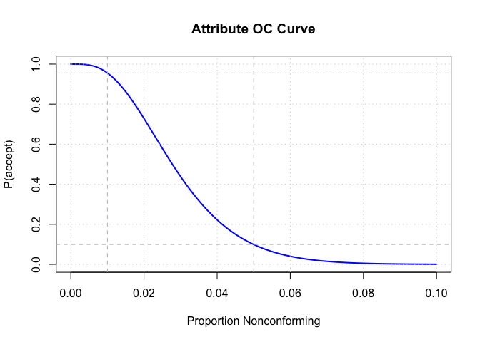

```r
plotOC(plan_attr)
```

# 4. Variable Sampling Plans

## 4.1 Normal Distribution

```r
norm_plan <- optVarPlan(
  PRQ = 0.025,        # Acceptable quality level (% nonconforming)
  CRQ = 0.1,         # Rejectable quality level (% nonconforming)
  alpha = 0.05,      # Producer's risk
  beta = 0.1,        # Consumer's risk
  distribution = "normal"
)

summary(norm_plan)
```

```
#> Variable Acceptance Sampling Plan
#> --------------------------------
#> Distribution: normal
#> Sample Size (n): 19
#> Acceptance Limit (k): 1.579
#> Population Standard Deviation: Known
#> Producer's Risk (alpha = 0.05 ) at PRQ = 0.025
#> Consumer's Risk (beta = 0.1 ) at CRQ = 0.1
```

## 4.2 Beta Distribution

```r
beta_plan <- optVarPlan(
  PRQ = 0.025,       # Target quality level (% nonconforming)
  CRQ = 0.1,       # Minimum quality level (% nonconforming)
  alpha = 0.05,      # Producer's risk
  beta = 0.1,        # Consumer's risk
  distribution = "beta",
  theta = 44000000,
  spec_limit = 0.00001, # Lower reliability limit
  limit_type = "lower"
)
summary(beta_plan)
```

```
#> Variable Acceptance Sampling Plan
#> --------------------------------
#> Distribution: beta
#> Sample Size (m): 20
#> Acceptance Constant (k): 1.555
#> Producer's Risk (alpha = 0.04999722 ) at PRQ = 0.025
#> Consumer's Risk (beta = 0.099894 ) at CRQ = 0.1
```

## 4.3 Variable Plan Acceptance Probability

```r
# Probability of accepting 10% defective
accProb(norm_plan, 0.1)
```

```
#> [1] 0.0997
```

```r
# Probability of accepting 5% defective
accProb(beta_plan, 0.05)
```

```
#> [1] 0.6118041
```

## 4.4 Variable OC Curves

```r
# Generate OC curve data
oc_data_normal <- OCdata(norm_plan)
# show data of Proportion Nonconforming (x_p) vs Probability Acceptance (y)
head(oc_data_normal, 15)
```

```
#>            x_p      y
#> 1  0.000000000 1.0000
#> 2  0.002020202 1.0000
#> 3  0.004040404 1.0000
#> 4  0.006060606 1.0000
#> 5  0.008080808 0.9998
#> 6  0.010101010 0.9993
#> 7  0.012121212 0.9982
#> 8  0.014141414 0.9960
#> 9  0.016161616 0.9923
#> 10 0.018181818 0.9867
#> 11 0.020202020 0.9788
#> 12 0.022222222 0.9685
#> 13 0.024242424 0.9554
#> 14 0.026262626 0.9397
#> 15 0.028282828 0.9212
```

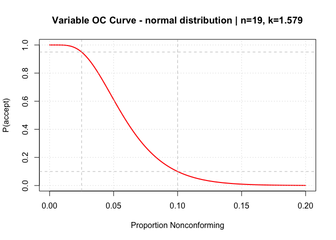

```r
plotOC(norm_plan)
```

```r
oc_data_beta <- OCdata(beta_plan)
head(oc_data_beta, 15)
```

```
#>            x_p         y
#> 1  0.000000000 1.0000000
#> 2  0.002020202 1.0000000
#> 3  0.004040404 0.9999980
#> 4  0.006060606 0.9999696
#> 5  0.008080808 0.9998179
#> 6  0.010101010 0.9993316
#> 7  0.012121212 0.9981860
#> 8  0.014141414 0.9959779
#> 9  0.016161616 0.9922760
#> 10 0.018181818 0.9866715
#> 11 0.020202020 0.9788169
#> 12 0.022222222 0.9684731
#> 13 0.024242424 0.9555369
#> 14 0.026262626 0.9399075
#> 15 0.028282828 0.9209765
```

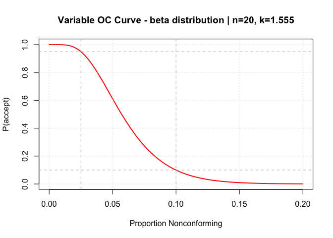

```r
plotOC(beta_plan)
```

# 5. Measurement Error Adjustment

```r
error_plan <- optAttrPlan(
  PRQ = 0.01,
  CRQ = 0.05,
  measurement_error = 0.2 # 20% measurement error
)
summary(error_plan)
```

```
#> Attribute Acceptance Sampling Plan
#> ----------------------------------
#> Sample Size (n): 132
#> Acceptance Number (c): 3
#> Producer's Risk (alpha = 0.04425251 ) at PRQ = 0.01
#> Consumer's Risk (beta = 0.0992283 ) at CRQ = 0.05
#> Measurement Error: 0.2
```

# 6. Technical Specifications

## 6.1 Attribute Plan:

$$P(accept|p) = \sum_{i=0}^c
\binom{n}{i}p^i(1-p)^{n-i}$$

## 6.2 Normal Variable Plan (Case of Known $\sigma$):

The Probability of Acceptance ($Pa$) is given by:

$$Pa = 1 - \Phi\left( \sqrt{n} \cdot (z_p + k) \right)$$

where:  
- $\Phi(\cdot)$ is the CDF of the standard normal distribution.  
- $z_p = \Phi^{-1}(p)$ is the standard normal quantile corresponding to the quality level $p$.  
- $n$ is the sample size.  
- $k$ is the acceptance constant.

The required sample size ($n$) and acceptance constant ($k$) are:
$$n = \left( \frac{z_{1 - \alpha} + z_{1 - \beta}}{z_{1 - PRQ} - z_{1 -
CRQ}} \right)^2$$

$$k = \frac{z_{1 - PRQ} \cdot z_{1 - \beta} + z_{1 - CRQ} \cdot z_{1 -
\alpha}}{z_{1 - \alpha} + z_{1 - \beta}}$$

where:  
- $\alpha$ and $\beta$ are the producer’s and consumer’s risks, respectively.  
- $PRQ$ and $CRQ$ are the Producer’s Risk Quality and Consumer’s Risk Quality, respectively.

(See Wilrich, PT. (2004) for more detail of calculation)

## 6.4 Beta Variable Plan:

Traditional acceptance sampling using normal distributions can be inadequate for compositional data bounded within [0,1]. Govindaraju and Kissling (2015) proposed Beta-based plans, where component proportions (e.g., protein content) follow $X \sim \text{Beta}(a, b)$, with density:

$$f(x; a, b) = \frac{x^{a-1} (1 - x)^{b-1}}{B(a, b)},$$

where $B(a, b)$ is the Beta function. The distribution is reparameterized via mean $\mu$ and precision $\theta$:

$$\mu = \frac{a}{a + b}, \quad \theta = a + b, \quad \sigma^2 \approx
\frac{\mu(1 - \mu)}{\theta} \quad (\text{for large } \theta).$$

Higher $\theta$ reduces variance, concentrating values around $\mu$. The probability of acceptance ($Pa$) parallels normal-based plans:

$$Pa = P(\mu - k \sigma \geq L \mid \mu, \theta, m, k),$$

where $L$ is the lower specification limit, $m$ is the sample size, and $k$ is the acceptability constant. Parameters $m$ and $k$ ensure:

$$Pa(\mu_{PRQ}) = 1 - \alpha, \quad Pa(\mu_{CRQ}) = \beta,$$

with $\alpha$ (producer’s risk) and $\beta$ (consumer’s risk) at specified quality levels (PRQ/CRQ).

### Implementation Note:

For a nonconforming proportion $p$ (e.g.,PRQ or CRQ), the mean $\mu$ at a quality level (PRQ/CRQ) is derived by solving:

$$P(X \leq L \mid \mu, \theta) = p,$$

where $X \sim \text{Beta}(\theta \mu, \theta (1 - \mu))$. This links $\mu$ to $p$ via the Beta cumulative distribution function (CDF) at $L$.

# 7. References

1. Schilling, E.G., & Neubauer, D.V. (2017). Acceptance Sampling in Quality Control (3rd ed.). Chapman and Hall/CRC. https://doi.org/10.4324/9781315120744
2. Wilrich, PT. (2004). Single Sampling Plans for Inspection by Variables under a Variance Component Situation. In: Lenz, HJ., Wilrich, PT. (eds) Frontiers in Statistical Quality Control 7. Frontiers in Statistical Quality Control, vol 7. Physica, Heidelberg. https://doi.org/10.1007/978-3-7908-2674-6_4
3. K. Govindaraju and R. Kissling (2015). Sampling plans for Beta-distributed compositional fractions. Quality Engineering, vol. 27, no. 1, pp. 1-13. https://doi.org/10.1016/j.chemolab.2015.12.009
4. ISO 2859-1:1999 - Sampling procedures for inspection by attributes
5. ISO 3951-1:2013 - Sampling procedures for inspection by variables